# George_Sturrock_NLP_Homework5

## Noun Phrase Chunking of IMDB Movie Reviews

### DS 7337 - Natural Laguage Processing - Homework 5

#### George C. Sturrock

##### March 2, 2019

##### Homework 5 Objectives

1. Compile a list of static links (permalinks) to individual user movie reviews from one particular website. This will be your working dataset for this assignment, as well as for assignments 7 and 8, which together will make up your semester project.  
   a. It does not matter if you use a crawler or if you manually collect the links, but you will need at least 100 movie review links. Note that, as of this writing, the robots.txt file of IMDB.com allows the crawling of user reviews. b. Each link should be to a web page that has only one user review of only one movie, e.g., the user review permalinks on the IMDB site. c. Choose reviews of movies that are all in the same genre, e.g., sci-fi, mystery, romance, superhero, etc.  
   d. Make sure your collection includes reviews of several movies in your chosen genre and that it includes a mix of negative and positive reviews.
2. Extract noun phrase (NP) chunks from your reviews using the following procedure: a. In Python, use BeautifulSoup to grab the main review text from each link.  
   b. Next run each review text through a tokenizer, and then try to NP-chunk it with a shallow parser. c. You probably will have too many unknown words, owing to proper names of characters, actors, and so on that are not in your working dictionary. Make sure the main names that are relevant to the movies in your collection of reviews are added to the working lexicon, and then run the NP chunker again.
3. Output all the chunks in a single list for each review, and submit that output for this assignment. Also submit a brief written summary of what you did (describe your selection of genre, your source of reviews, how many you collected, and by what means).

#### Import Libraries

```python
import platform; print("Platform:", platform.platform())
import os
import sys; print("Python:", sys.version)
import requests; print("Requests:", requests.__version__)
from urllib import request; ("urllib:", request.__version__)
import warnings
warnings.filterwarnings('ignore')
from time import sleep

#Web Scraping
import bs4; print("BeatifulSoup:", bs4.__version__)
from bs4 import BeautifulSoup
import json; print("json:", json.__version__)

#Python Basics
import numpy as np; print("Numpy Version:", np.__version__)
import pandas as pd; print("Pandas Version:", pd.__version__)
import seaborn as sns;

#NLP
import nltk; print("NLTK Version:", nltk.__version__)
#nltk.download('conll2000')
from nltk.corpus import conll2000

import spacy; print("Spacy Version:", spacy.__version__)
from spacy import displacy
#nlp = spacy.load('en')
import en_core_web_sm; print("en_core_web_sm Version:", en_core_web_sm.__version__)
nlp = en_core_web_sm.load()
#import en_core_web_md; print("en_core_web_md Version:", en_core_web_md.__version__)
#nlp = en_core_web_md.load()

import pattern; print("Pattern Version:", pattern.__version__)
from pattern.en import tag
from pattern.en import parsetree
```

```
Platform: Windows-10-10.0.14393-SP0
Python: 3.6.8 |Anaconda custom (64-bit)| (default, Feb 11 2019, 15:03:47) [MSC v.1915 64 bit (AMD64)]
Requests: 2.21.0
BeatifulSoup: 4.7.1
json: 2.0.9
Numpy Version: 1.15.4
Pandas Version: 0.24.1
NLTK Version: 3.4
Spacy Version: 2.0.16
en_core_web_sm Version: 2.0.0
Pattern Version: 3.6
```

#### Question 5.1

For this assignment, the first three films in the "Rocky" series will be utilized to collect reviews for noun phrase chunking. Link to the main user review page for each of the three movies are shown below. To assure both positive and negative reviews are collected, there are two links per movie. One is sorted descending by user rating. The other is sorted ascending by user rating. Both links have "spoiler alert" messages suppressed as these reviews are often more akin to a summarization of the movie plot instead of a true review.

```python
#Rocky movie list.  Two links for each movie to assure positive and negative reviews are captured.
#Sort descending by Review Rating.  Sort ascending by Review Rating.

#Rocky
rockyDict = {"aRocky":"https://www.imdb.com/title/tt0075148/reviews?spoiler=hide&sort=userRating&dir=asc&ratingFilter=0",
         "dRocky":"https://www.imdb.com/title/tt0075148/reviews?spoiler=hide&sort=userRating&dir=desc&ratingFilter=0",
#Rocky 2
         "dRocky 2":"https://www.imdb.com/title/tt0079817/reviews?spoiler=hide&sort=userRating&dir=desc&ratingFilter=0",
         "aRocky 2":"https://www.imdb.com/title/tt0079817/reviews?spoiler=hide&sort=userRating&dir=asc&ratingFilter=0",
#Rocky 3
         "dRocky 3":"https://www.imdb.com/title/tt0084602/reviews?spoiler=hide&sort=userRating&dir=desc&ratingFilter=0",
         "aRocky 3":"https://www.imdb.com/title/tt0084602/reviews?spoiler=hide&sort=userRating&dir=asc&ratingFilter=0"
            }

rockyKeys = rockyDict.keys()
```

The individual links to the user reviews are collected below. A get request uses each of the links in the "rockyDict" python dictionary. The response is parsed by Beautiful Soup to find the individual links to each individual review. The review URLs along with the movie name are written to a dataframe named dfRockyReviews.

```python
reviewUrls = list()
dfRockyReviews = pd.DataFrame(columns = ['Movie', 'ReviewURL'])

for r in rockyKeys:
    #print(r, rockyDict[r])
    response = requests.get(rockyDict[r])
    soup = BeautifulSoup(response.text, 'html.parser')
    rUrls = ["http:" + s.attrs['href'] for s in soup.find_all(href = True, class_ = 'title')]
    reviewUrls = reviewUrls + rUrls
    for u in rUrls:
        dfRockyReviews = dfRockyReviews.append({'Movie':r[1:], 'ReviewURL':u}, ignore_index=True)
```

A sample of the dfRockyReviews dataframe is shown below.

```python
dfRockyReviews[0:5]
```

|  | Movie | ReviewURL |
| --- | --- | --- |
| 0 | Rocky | http:/review/rw0149538/?ref_=tt_urv |
| 1 | Rocky | http:/review/rw4247059/?ref_=tt_urv |
| 2 | Rocky | http:/review/rw0149534/?ref_=tt_urv |
| 3 | Rocky | http:/review/rw3451942/?ref_=tt_urv |
| 4 | Rocky | http:/review/rw2406266/?ref_=tt_urv |

#### 5.2

The individual review URLs collected above will be requested and parsed to retrieve key qualitative and categorical data about each review along with the review text itself. These details are stored in a new dataframe named dfReviewDetails. The first five records are this dataframe are shown below.

```python
dfReviewDetails = pd.DataFrame(columns=['Movie', 'ReviewUrl', 'ReviewDate', 'ReviewTitle', 'Review', 'Rating',
                                        'Language'])
counter = 0

for r in reviewUrls:
    fullUrl = "https://www.imdb.com" + r[5:]
    response2 = requests.get(fullUrl)
    soup2 = BeautifulSoup(response2.text, 'html.parser')
    rjson = soup2.find('script', type = 'application/ld+json').text
    rjson = json.loads(rjson)

    try:
        rating = rjson['reviewRating']['ratingValue']
    except Exception as e:
        #print("No User Rating")
        rating = 5

    dfReviewDetails = dfReviewDetails.append({'Movie':dfRockyReviews.Movie[counter], 'ReviewUrl':r,
                                              'ReviewDate':rjson['dateCreated'], 'ReviewTitle':rjson['name'],
                                              'Review':rjson['reviewBody'], 'Rating':rating,
                                              'Language':rjson['inLanguage']}, ignore_index=True)
    counter += 1

dfReviewDetails[0:5]
```

|  | Movie | ReviewUrl | ReviewDate | ReviewTitle | Review | Rating | Language |
| --- | --- | --- | --- | --- | --- | --- | --- |
| 0 | Rocky | http:/review/rw0149538/?ref_=tt_urv | 1999-11-25 | Dumbest, Most Cornball Film Ever Made | I still remember my initial outrage that this ... | 1 | English |
| 1 | Rocky | http:/review/rw4247059/?ref_=tt_urv | 2018-07-21 | Rubbish | The fight scenes are pathetic and the acting i... | 1 | English |
| 2 | Rocky | http:/review/rw0149534/?ref_=tt_urv | 1998-08-19 | overrated piece of cheese | grubby late-night fare achieved way too much s... | 2 | English |
| 3 | Rocky | http:/review/rw3451942/?ref_=tt_urv | 2016-04-15 | Hate me if you want but I didn't like this film | I'm going to come out and say it. I didn't lik... | 3 | English |
| 4 | Rocky | http:/review/rw2406266/?ref_=tt_urv | 2011-03-30 | I can't believe the script was made into a mov... | I was told by many that Rocky is a beautiful m... | 3 | English |

The bar plot below shows movie review ratings for the reviews collected in the prior step. The original "Rocky" is widely considered the best of the "Rocky" series. It won multiple Oscars and introduced "Steady-Cam" technology to the movie world. However, the sample of user reviews collected tell a different story.

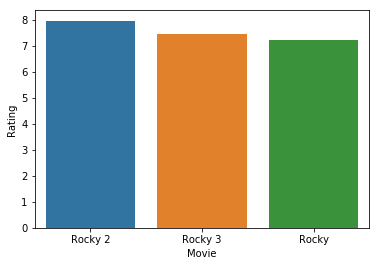

```python
plotdf = dfReviewDetails.sort_values(by=['ReviewDate'])
plotdf.Rating = plotdf.Rating.astype('int64')
plotdf.ReviewDate = pd.to_datetime(plotdf.ReviewDate)
plotdf = plotdf.groupby(['Movie']).mean().reset_index()
sns.barplot(x='Movie', y='Rating', data=plotdf.sort_values(by=['Rating'], ascending=False))
```

#### 5.3 - Spacy Chunking

Question 5.3 requires a list of noun phrase chunks from each sentence in the movie reviews collected above. Though the request is for a single list of noun phrase chunks, the results from both Spacy and Pattern chunking are shown below. First, the Spacy chunks are generated. The results of the Spacy chunker are impressive. Visual examination of the results shown proper nouns are mostly handled accurately, and the noun phrases are accurately identified. Futhermore, the process takes under five minutes are a modestly powered machine with a .5 second sleep per loop. The chunk labels, which should be restricted to "NP" (noun phrase), noun phrase texts, part-of-speech tags, and the chunk roots are displayed for each chunk.

```python
%%time

for r, m, t in zip(dfReviewDetails.Review, dfReviewDetails.Movie, dfReviewDetails.ReviewTitle):
    #Spacy Chunking
    doc = nlp(r)
    print("===================================================================================")
    print("===  Movie:", m, "Review Title:", t)
    print("===================================================================================")
    for chunk in doc.noun_chunks:
        #print(chunk.label_, "|| Text:", chunk.text, "|| Phrase Root:", chunk.root.text)
        print(chunk.label_, "|| Phrase Root:", chunk.root.text, "||", [(c.text, c.pos_) for c in chunk])
    print("===================================================================================")
    print("=================================== End Review ====================================")
    print("===================================================================================")
    sleep(0.5)
```

```
===================================================================================
===  Movie: Rocky Review Title: Rubbish
===================================================================================
NP || Phrase Root: scenes || [('The', 'DET'), ('fight', 'NOUN'), ('scenes', 'NOUN')]
NP || Phrase Root: acting || [('the', 'DET'), ('acting', 'NOUN')]
===================================================================================
=================================== End Review ====================================
===================================================================================
===================================================================================
===  Movie: Rocky Review Title: Dumbest, Most Cornball Film Ever Made
===================================================================================
NP || Phrase Root: I || [('I', 'PRON')]
NP || Phrase Root: outrage || [('my', 'ADJ'), ('initial', 'ADJ'), ('outrage', 'NOUN')]
NP || Phrase Root: piece || [('this', 'DET'), ('piece', 'NOUN')]
NP || Phrase Root: slop || [('sentimental', 'ADJ'), ('slop', 'NOUN')]
NP || Phrase Root: they || [('they', 'PRON')]
NP || Phrase Root: movie || [('this', 'DET'), ('movie', 'NOUN')]
NP || Phrase Root: cliches || [('so', 'ADV'), ('many', 'ADJ'), ('cliches', 'NOUN')]
NP || Phrase Root: stupidities || [('stupidities', 'NOUN')]
NP || Phrase Root: it || [('it', 'PRON')]
NP || Phrase Root: time || [('all', 'DET'), ('time', 'NOUN')]
NP || Phrase Root: Hollywood || [('just', 'ADV'), ('how', 'ADV'), ('ignorant', 'ADJ'), ('Hollywood', 'PROPN')]
NP || Phrase Root: public || [('the', 'DET'), ('movie', 'NOUN'), ('-', 'PUNCT'), ('going', 'VERB'), ('public', 'NOUN')]
===================================================================================
=================================== End Review ====================================
===================================================================================
===================================================================================
===  Movie: Rocky Review Title: overrated piece of cheese
===================================================================================
NP || Phrase Root: fare || [('grubby', 'ADJ'), ('late', 'ADJ'), ('-', 'PUNCT'), ('night', 'NOUN'), ('fare', 'NOUN')]
NP || Phrase Root: success || [('way', 'NOUN'), ('too', 'ADV'), ('much', 'ADJ'), ('success', 'NOUN')]
NP || Phrase Root: story || [('a', 'DET'), ('primitive', 'ADJ'), ('story', 'NOUN')]
NP || Phrase Root: song || [('A', 'DET'), ('silly', 'ADJ'), ('promotional', 'ADJ'), ('song', 'NOUN')]
NP || Phrase Root: script || [('laughable', 'ADJ'), ('script', 'NOUN')]
NP || Phrase Root: performances || [('performances', 'NOUN')]
NP || Phrase Root: I || [('I', 'PRON')]
NP || Phrase Root: clue || [('no', 'DET'), ('clue', 'NOUN')]
NP || Phrase Root: picture || [('this', 'DET'), ('picture', 'NOUN')]
NP || Phrase Root: heart || [('its', 'ADJ'), ('heart', 'NOUN')]
NP || Phrase Root: sleeve || [('its', 'ADJ'), ('sleeve', 'NOUN')]
```

[output cut: 10254 more lines]

```
NP || Phrase Root: score || [('Bill', 'PROPN'), ('Conti', 'PROPN'), ("'s", 'PART'), ('score', 'NOUN')]
NP || Phrase Root: what || [('what', 'NOUN')]
NP || Phrase Root: people || [('most', 'ADJ'), ('people', 'NOUN')]
NP || Phrase Root: one || [('this', 'DET'), ('one', 'NOUN')]
NP || Phrase Root: song || [('Survivor', 'PROPN'), ("'s", 'PART'), ('hit', 'NOUN'), ('song', 'NOUN')]
NP || Phrase Root: Eye || [('Eye', 'PROPN')]
NP || Phrase Root: Tiger || [('the', 'DET'), ('Tiger', 'PROPN')]
NP || Phrase Root: movie || [('Not', 'ADV'), ('a', 'DET'), ('bad', 'ADJ'), ('movie', 'NOUN')]
NP || Phrase Root: way || [('any', 'DET'), ('way', 'NOUN')]
NP || Phrase Root: step || [('a', 'DET'), ('step', 'NOUN')]
NP || Phrase Root: part || [('part', 'NOUN')]
===================================================================================
=================================== End Review ====================================
===================================================================================
Wall time: 4min 58s
```

#### 5.3 - Pattern Chunking

The Pattern modules parsetree also provides a method for sentence chunking as well. The Pattern chunking also identifies noun phrases while also showing part of speech tags. Additionally, certain proper names such as "Sylvester Stallone" are recongnized as the name of a person. Even with a 0.5 second sleep for each journey through the for loop (too control the rate of messages sent through the jupyter server), the pattern chunker only takes approximately 3 minutes to complete its work on the same server as the Spacy chunker.

```python
%%time

for r, m, t in zip(dfReviewDetails.Review, dfReviewDetails.Movie, dfReviewDetails.ReviewTitle):
    print("===================================================================================")
    print("===  Movie:", m, "Review Title:", t)
    print("===================================================================================")
    pt = parsetree(r)
    for p in pt:
        for chunk in p.chunks:
            if chunk.type == 'NP':
                print(chunk.type, "||", "Head Word:", chunk.head, "||", [(w.string, w.type) for w in chunk.words])
    print("===================================================================================")
    print("=================================== End Review ====================================")
    print("===================================================================================")
    sleep(0.5)
```

```
===================================================================================
===  Movie: Rocky Review Title: Rubbish
===================================================================================
NP || Head Word: scenes || [('The', 'DT'), ('fight', 'NN'), ('scenes', 'NNS')]
NP || Head Word: acting || [('the', 'DT'), ('acting', 'NN')]
NP || Head Word: Rubbish || [('Rubbish', 'NN')]
===================================================================================
=================================== End Review ====================================
===================================================================================
===================================================================================
===  Movie: Rocky Review Title: Dumbest, Most Cornball Film Ever Made
===================================================================================
NP || Head Word: I || [('I', 'PRP')]
NP || Head Word: outrage || [('my', 'PRP$'), ('initial', 'JJ'), ('outrage', 'NN')]
NP || Head Word: piece || [('this', 'DT'), ('piece', 'NN')]
NP || Head Word: slop || [('sentimental', 'JJ'), ('slop', 'NN')]
NP || Head Word: they || [('they', 'PRP')]
NP || Head Word: movie || [('this', 'DT'), ('movie', 'NN')]
NP || Head Word: cliches || [('so', 'RB'), ('many', 'JJ'), ('cliches', 'NNS')]
NP || Head Word: stupidities || [('stupidities', 'NNS')]
NP || Head Word: it || [('it', 'PRP')]
NP || Head Word: time || [('all', 'DT'), ('time', 'NN')]
NP || Head Word: Hollywood || [('ignorant', 'JJ'), ('Hollywood', 'NNP')]
NP || Head Word: public || [('public', 'NN')]
===================================================================================
=================================== End Review ====================================
===================================================================================
===================================================================================
===  Movie: Rocky Review Title: overrated piece of cheese
===================================================================================
NP || Head Word: fare || [('grubby', 'JJ'), ('late-night', 'JJ'), ('fare', 'NN')]
NP || Head Word: success || [('way', 'NN'), ('too', 'RB'), ('much', 'JJ'), ('success', 'NN')]
NP || Head Word: story || [('a', 'DT'), ('primitive', 'JJ'), ('story', 'NN')]
NP || Head Word: song || [('A', 'DT'), ('silly', 'JJ'), ('promotional', 'JJ'), ('song', 'NN')]
NP || Head Word: script || [('laughable', 'JJ'), ('script', 'NN')]
NP || Head Word: performances || [('performances', 'NNS')]
NP || Head Word: I || [('I', 'PRP')]
NP || Head Word: clue || [('no', 'DT'), ('clue', 'NN')]
NP || Head Word: picture || [('this', 'DT'), ('picture', 'NN')]
NP || Head Word: heart || [('its', 'PRP$'), ('heart', 'NN')]
```

[output cut: 10090 more lines]

```
NP || Head Word: score || [('score', 'NN')]
NP || Head Word: people || [('most', 'JJS'), ('people', 'NNS')]
NP || Head Word: one || [('this', 'DT'), ('one', 'NN')]
NP || Head Word: Survivor || [('Survivor', 'NNP')]
NP || Head Word: song || [('hit', 'NN'), ('song', 'NN')]
NP || Head Word: Eye || [('Eye', 'NNP')]
NP || Head Word: Tiger || [('the', 'DT'), ('Tiger', 'NNP')]
NP || Head Word: movie || [('a', 'DT'), ('bad', 'JJ'), ('movie', 'NN')]
NP || Head Word: way || [('any', 'DT'), ('way', 'NN')]
NP || Head Word: step || [('a', 'DT'), ('step', 'NN')]
NP || Head Word: part || [('part', 'NN')]
===================================================================================
=================================== End Review ====================================
===================================================================================
Wall time: 3min 4s
```

Spacy and Pattern were both used to produced similar information for each noun chunk. Both appear to be fairly effective at identifying proper nouns. However, Pattern did a better job identifying proper nouns as people. For this data set, Pattern was also more efficient in completing the work in approximately three minutes compared to five minutes for Spacy.